TOP AI STOCK PERFORMANCE

This table summarises the performance of top 14 AI Stocks by Market Cap (May 2024)

Company

Current Price  
(13 Jun 2024)

% Change in Price  
(Daily)

Weekly % Change in Price

52-Week High

52-Week Low

Price Trend

Current  
Volume

% Change in Volume  
(Daily)

Volume Trend

[figure not shown]

MICROSOFT CORPORATION

SYMBOL: MSFT

$441.58

▲ 0.12%

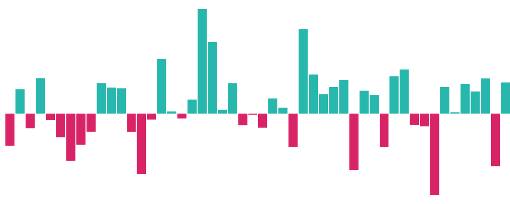

$441.58

$310.37

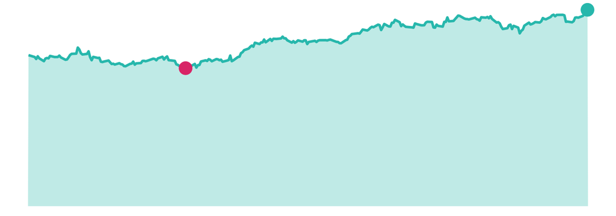

15.90M

▼ -28.93%

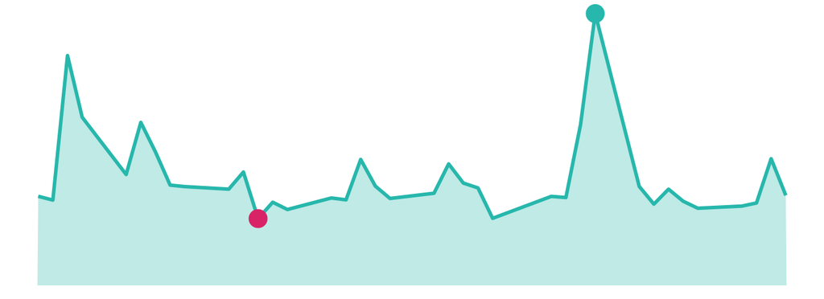

[figure not shown]

NVIDIA CORPORATION

SYMBOL: NVDA

$129.61

▲ 3.52%

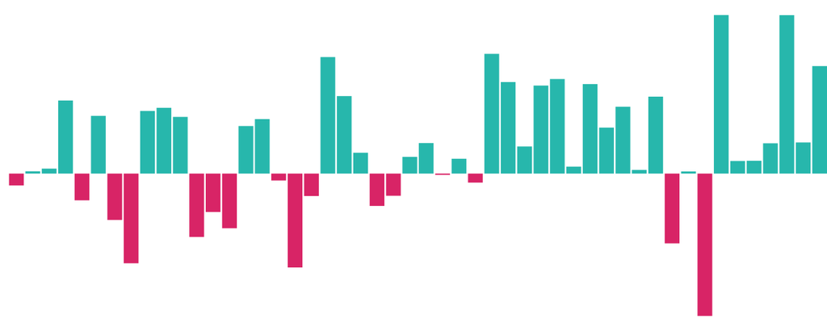

$129.61

$40.32

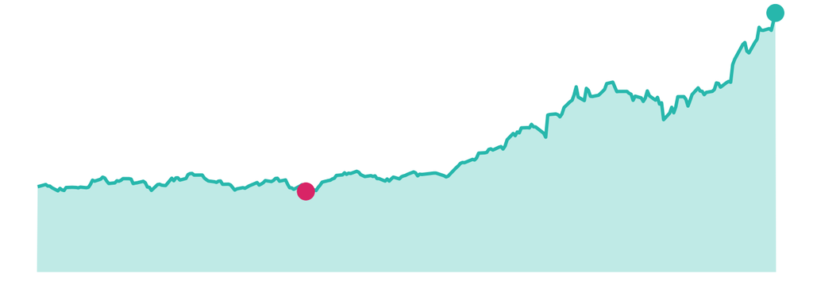

255.60M

▼ -14.69%

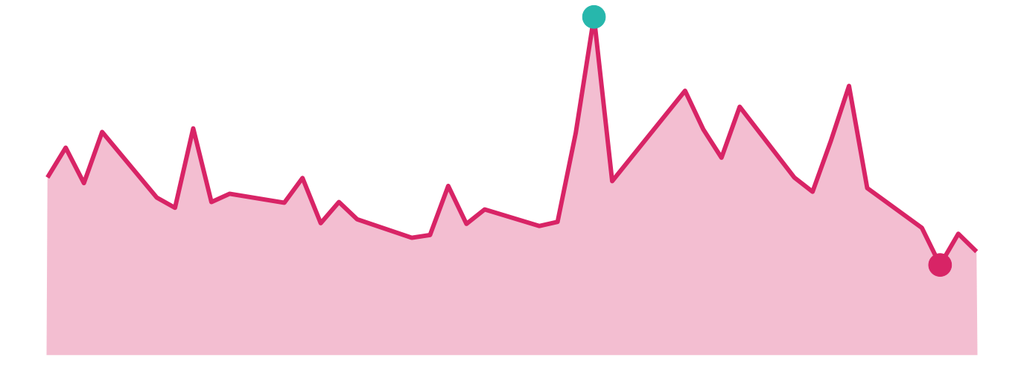

[figure not shown]

ALPHABET INC.

SYMBOL: GOOG

$176.74

▼ -1.57%

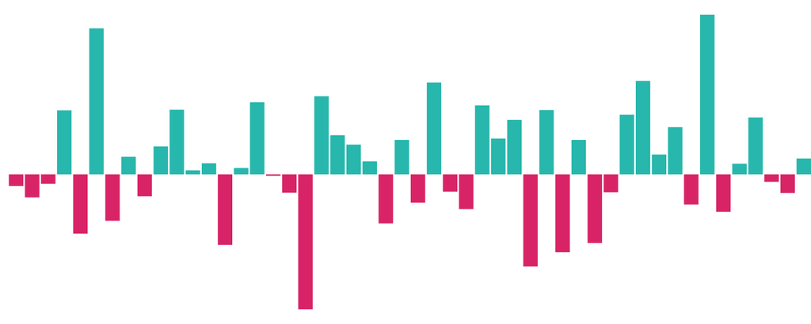

$179.56

$116.74

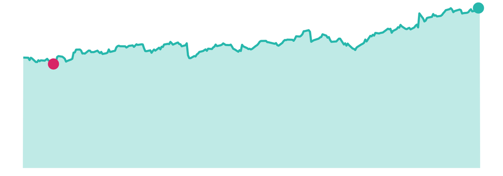

15.74M

▼ -15.35%

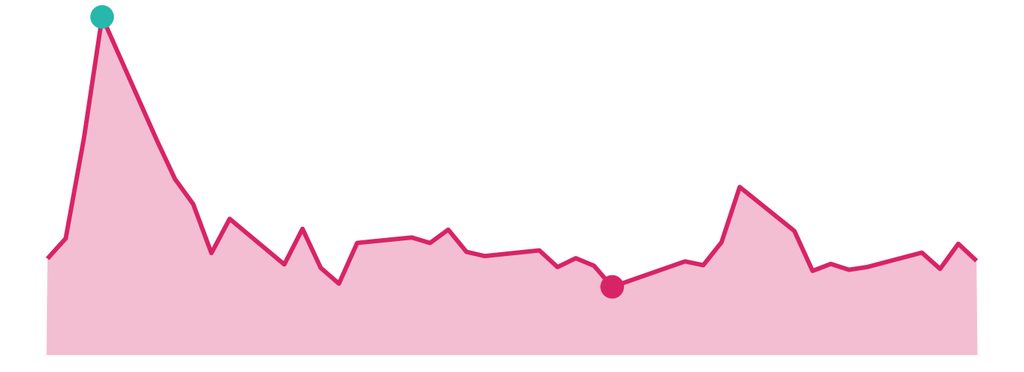

[figure not shown]

META PLATFORMS, INC.

SYMBOL: META

$504.10

▼ -0.93%

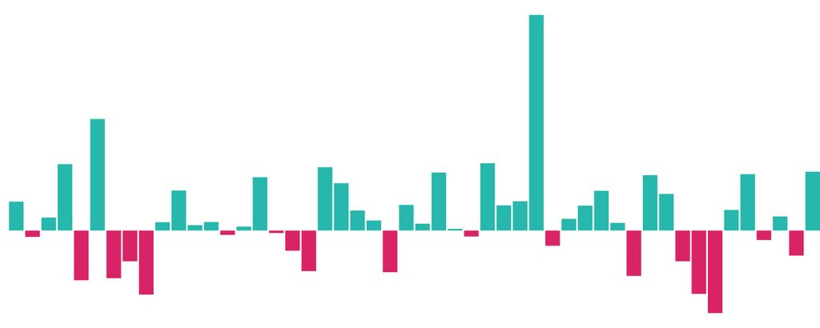

$527.34

$278.17

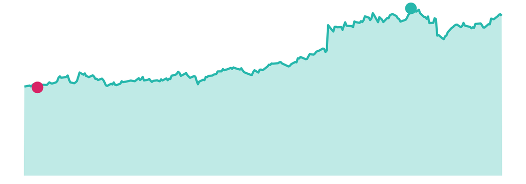

7.93M

▼ -33.83%

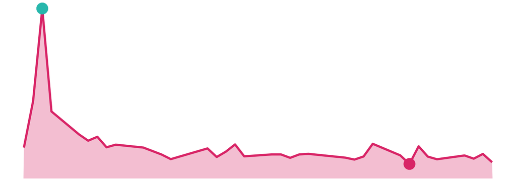

[figure not shown]

TESLA, INC.

SYMBOL: TSLA

$182.47

▲ 2.92%

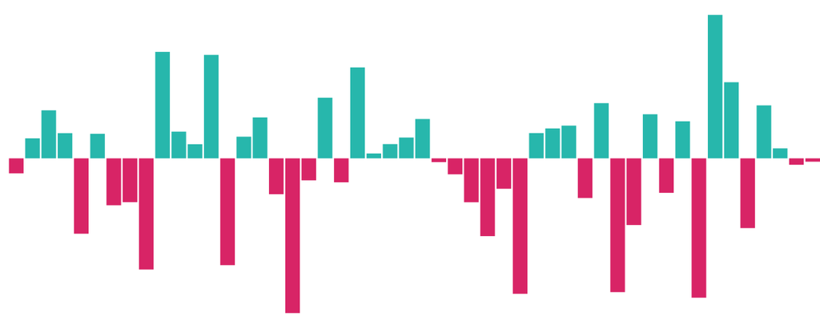

$293.34

$142.05

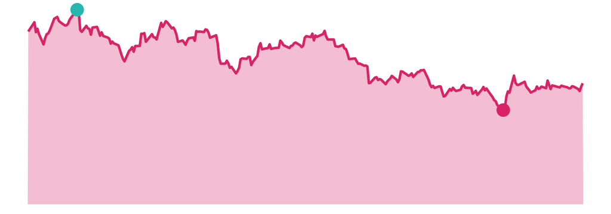

115.71M

▲ 28.01%

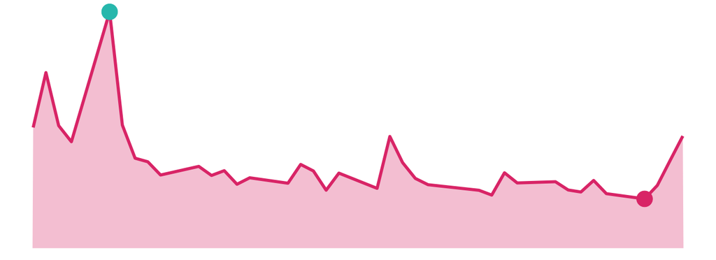

[figure not shown]

ADOBE INC.

SYMBOL: ADBE

$458.74

▼ -0.25%

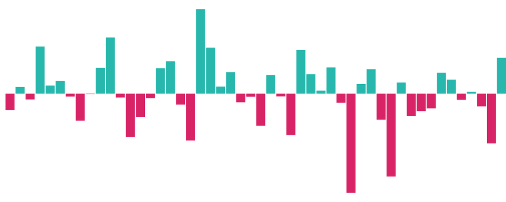

$634.76

$439.02

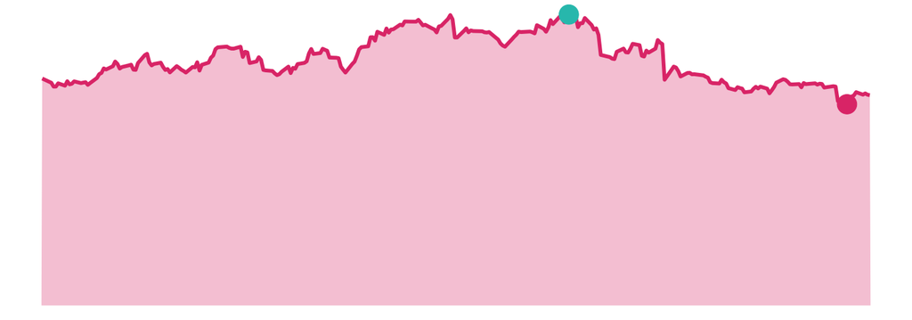

7.63M

▲ 109.14%

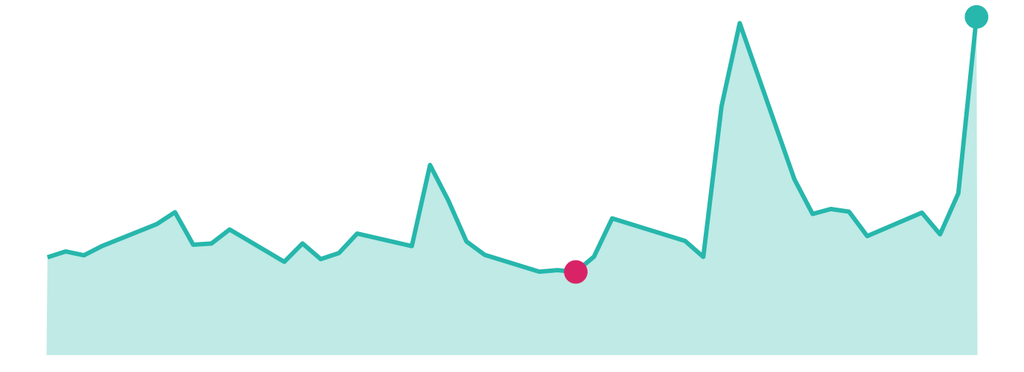

[figure not shown]

IBM CORPORATION

SYMBOL: IBM

$169.12

▲ 0.07%

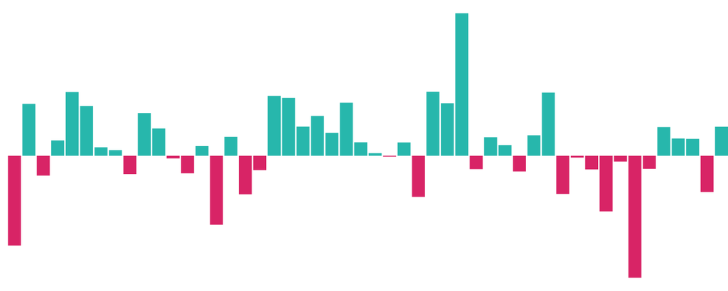

$195.84

$124.15

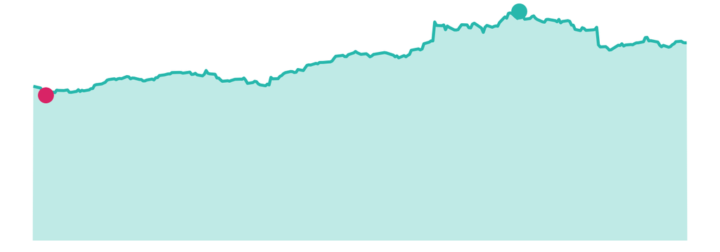

3.28M

▼ -6.91%

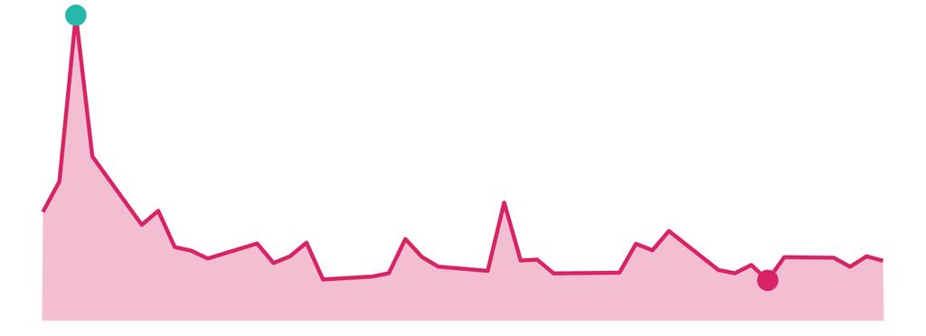

[figure not shown]

PALANTIR TECHNOLOGIES INC.

SYMBOL: PLTR

$23.27

▼ -2.10%

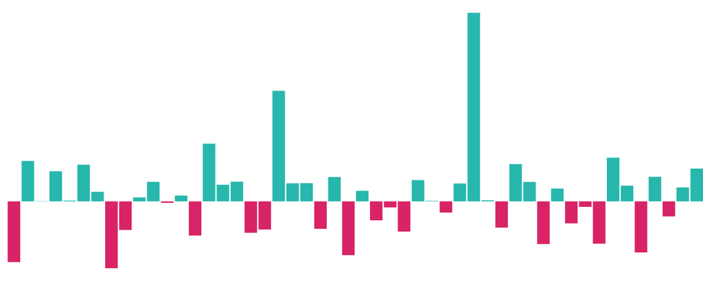

$26.46

$13.94

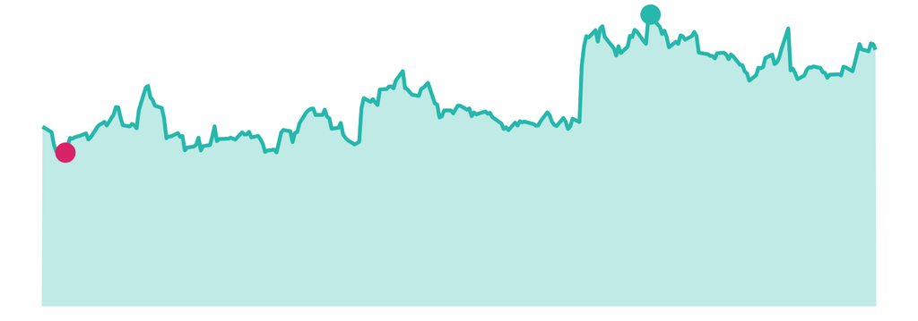

25.76M

▼ -33.18%

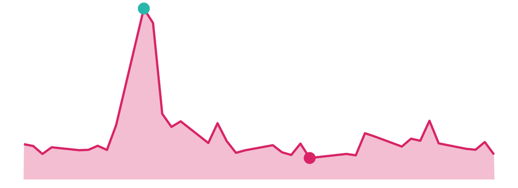

[figure not shown]

MOBILEYE GLOBAL INC.

SYMBOL: MBLY

$29.09